# Projekt 1-2

Anna Wójcik, Grzegorz Ziajka, Dawid Dąbkowski

24 marca 2017

Biblioteki i skrypty:

```r
library("ggplot2")
library("tidyr")
library("dplyr")
library("foreign")
library("MASS")
library("lmtest")
```

### Punkt 1 i 2 projektu

Zbadamy co wypływa na czas rozwiązywania zadań przez uczniów (T). Analizie poddamy objaśniające zmienne jakościowe: - M (numer zadania) - Q (numer podpunktu) - position (kolejność występowania w teście, od 1 do 4) W celu objaśnienia zmiennej ilościowej: - T (czas rozwiązywania podpunktu w sekundach)

W kolejnych punktach przygotujemy dane do analizy, stworzymy modele jedno- oraz dwuwymiarowe (także z zagnieżdżanniem i typu crossed). Wykonamy analizy warancji jedno- i dwukierunkowe i wyprowadzimy wnioski z uzyskanych modeli.

## Przygotowanie danych

Przygotujemy dane do analizy. Usuniemy wszystkie rekordy, w których interesujące nas zmienne są NA (lub -1).

```r
load("actionTimeScoreGender.rda") # dane o zadaniach z matematyki plus plec
dane <- actionTimeScoreGender
rm(actionTimeScoreGender)

dane <- separate(dane, item_short, into = c('M', 'Q'), sep = 4)
#dane$MQ <- paste(dane$M, dane$Q)
dane$M <- as.factor(dane$M)
dane$Q <- as.factor(dane$Q)
dane$position <- replace(dane$position, dane$position==-1, NA)
dane <- dane[complete.cases(dane),]

indeksy <- quantile(dane$T, probs=c(0.01, 0.99))
dane <- filter(dane, T<=indeksy[2])
dane <- filter(dane, T>=indeksy[1])
rm(indeksy)
dane <- droplevels(dane) # usuwamy brakujące poziomy factor-ów

summary(dane) # podsumowanie
```

```
##     CNTSTUID         ST004D01T              CNT
##  Min.   : 3600001   Female:1334310   QES      : 189435
##  1st Qu.:19103252   Male  :1327726   BRA      : 120175
##  Median :44003571                    CAN      : 119777
##  Mean   :47313416                    QAT      :  90220
##  3rd Qu.:75205778                    AUS      :  85816
##  Max.   :97311288                    GBR      :  84217
##                                      (Other)  :1972396
##     CNTSCHID            BOOKID              M             Q
##  Min.   : 3600001   45     : 215457   M982   : 215366   Q01:1637813
##  1st Qu.:19100082   49     : 209790   M909   : 156938   Q02: 562936
##  Median :44000151   50     : 201359   M949   : 109228   Q03: 265839
##  Mean   :47306795   44     : 201176   M496   : 106016   Q04: 195448
##  3rd Qu.:75200189   43     : 200786   M915   : 104510
##  Max.   :97300000   46     : 198910   M564   : 104340
##                     (Other):1434558   (Other):1865638
##  subject            A                         S
##  CM:2662036   Min.   :   0.000   Full credit   :1271712
##               1st Qu.:   3.000   No credit     :1388001
##               Median :   5.000   Partial credit:   2323
##               Mean   :   9.717
##               3rd Qu.:   9.000
##               Max.   :9114.000
##
##        T           position
##  Min.   :  3.098   1:677793
##  1st Qu.: 47.135   2:649485
##  Median : 73.194   3:676712
##  Mean   : 85.570   4:658046
##  3rd Qu.:110.962
##  Max.   :325.991
##
```

## Analiza jednokierunkowa

### Histogram zmiennej objaśnianej - czas rozwiązywania podpunktu (T)

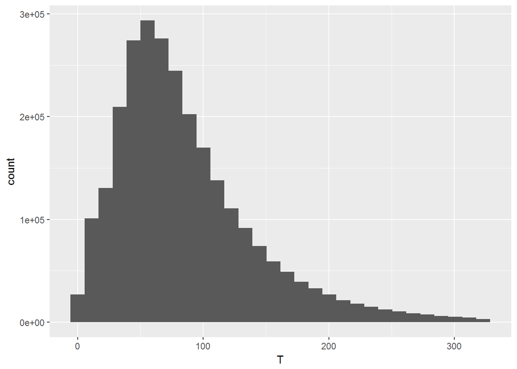

```r
ggplot(dane, aes(T)) + geom_histogram()
```

Zmienna objaśniana ma bardzo dużą rozpiętość czasów pomimo tego, że większość czasów mieści się w przedziale 0.5 do 2 minut (nawet po usunięciu lewego i prawego ogona). W przyszłości będziemy dążyć do tego, by wprowadzić odpowiednią transformację z rodziny boxa-coxa. Na razie stosować będziemy transformację pierwiastkową, która zmniejszy problem dużej rozpiętości czasów i normalności reszt.

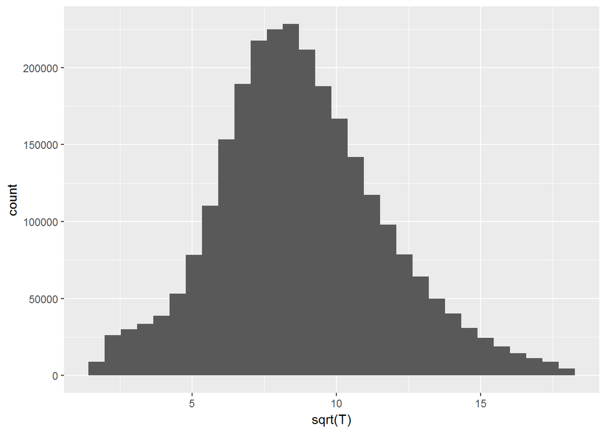

```r
ggplot(dane, aes(sqrt(T))) + geom_histogram()
```

### Model 1 - zależność między czasem (T) a id zadania (M)

```r
invisible(gc())
a1 <- aov(sqrt(T)~M, data=dane)
summary(a1)
```

```
##                  Df   Sum Sq Mean Sq F value Pr(>F)
## M                40  3028074   75702   10332 <2e-16 ***
## Residuals   2661995 19504970       7
## ---
## Signif. codes:  0 '***' 0.001 '**' 0.01 '*' 0.05 '.' 0.1 ' ' 1
```

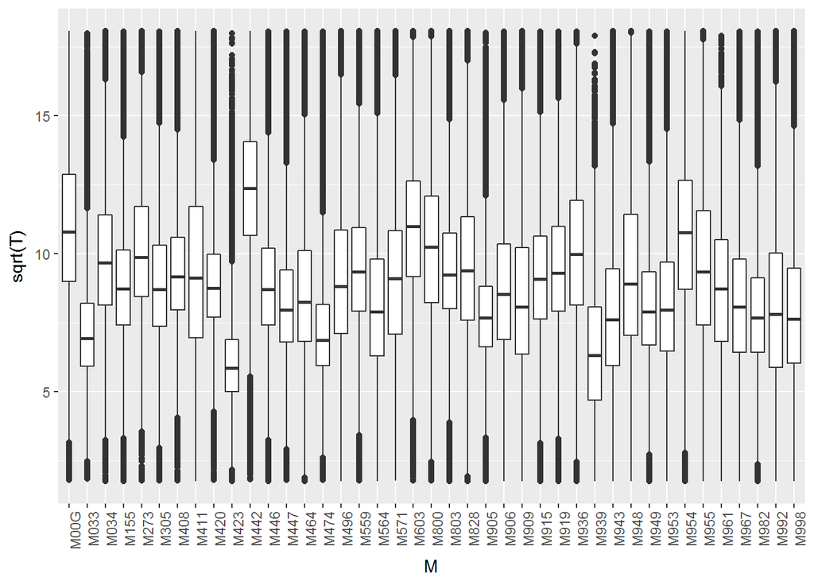

```r
ggplot(dane, aes(M, sqrt(T))) + geom_boxplot() + theme(axis.text.x = element_text(angle = 90, hjust = 1))
```

Widzimy, że różne zadania mają istotnie różne średnie. Może to wynikać z tego, że różne zadania mają różną trudność, złożoność i tematykę, przez co czas rozwiązywania podpunktów jest istotnie różny. Warto zwrócić uwagę, że zadania o wielu podpunktach będą tutaj silniej wpływały na model. Porównamy jeszcze parami, które zadania się różnią, za pomocą testu HSD Tukeya.

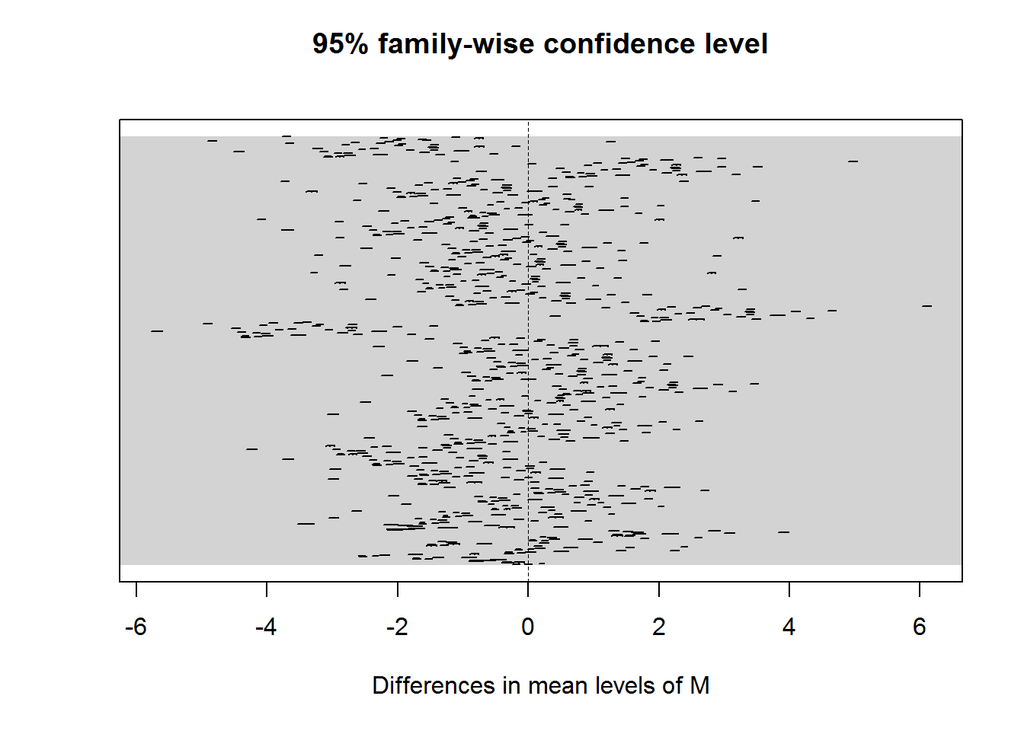

```r
invisible(gc())
t1 <- TukeyHSD(a1)
plot(t1, las=1, yaxt='n', ann=FALSE)
```

```r
rm(a1)
rm(t1)
```

Jak widać z wykresu, przedziały ufności dla bardzo wielu par zadań nie zawierają 0. Wnioskujemy, że między czasami rozwiązywania podpunktu są bardzo duże różnice.

### Model 2 - zależność między czasem (T) a pozycją w kwestionariuszu (position)

```r
invisible(gc())
a2 <- aov(sqrt(T)~position, data=dane)
summary(a2)
```

```
##                  Df   Sum Sq Mean Sq F value Pr(>F)
## position          3   415210  138403   16658 <2e-16 ***
## Residuals   2662032 22117834       8
## ---
## Signif. codes:  0 '***' 0.001 '**' 0.01 '*' 0.05 '.' 0.1 ' ' 1
```

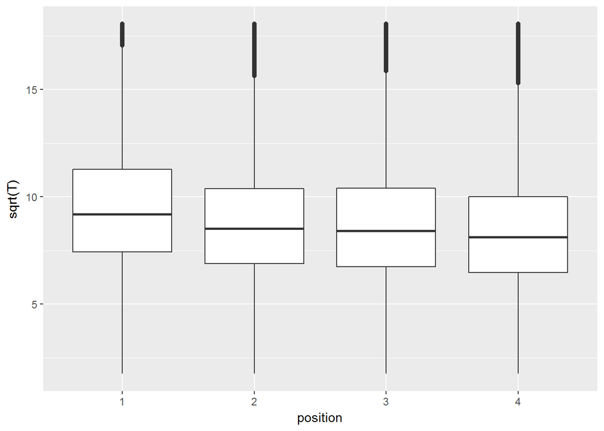

```r
ggplot(dane, aes(position, sqrt(T))) + geom_boxplot()
```

Różnice między średnimi czasami są istotne. Na wykresie można zauważyć, że im wcześniej podpunkt zadania był usytuowany w teście, tym więcej zajmował czasu. Może to wynikać z tego, że uczniowie mieli niedostatecznie dużo czasu i pod koniec działali już pod jego presją. Oczywiście mogą tu wchodzić też inne czynniki np. to, że w czasie rozwiązywania uczniowie nabierali wprawy. Zobaczmy jeszcze, które numery pozycji różnią się istotnie.

```r
invisible(gc())
t2 <- TukeyHSD(a2)
t2
```

```
##   Tukey multiple comparisons of means
##     95% family-wise confidence level
##
## Fit: aov(formula = sqrt(T) ~ position, data = dane)
##
## $position
##            diff        lwr         upr p adj
## 2-1 -0.69371520 -0.7065735 -0.68085695     0
## 3-1 -0.73641543 -0.7491409 -0.72368996     0
## 4-1 -1.08456640 -1.0973819 -1.07175093     0
## 3-2 -0.04270023 -0.0555635 -0.02983695     0
## 4-2 -0.39085119 -0.4038035 -0.37789888     0
## 4-3 -0.34815097 -0.3609715 -0.33533046     0
```

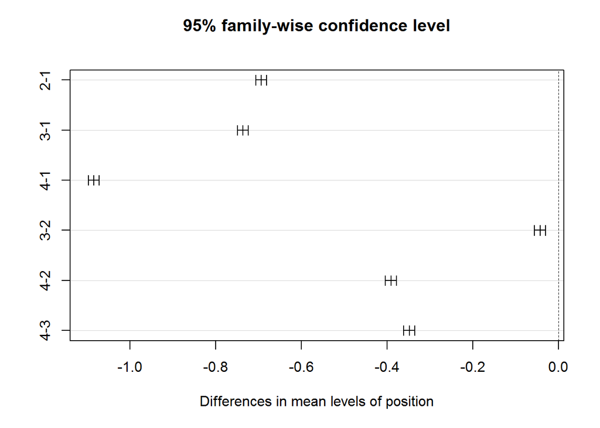

```r
plot(t2)
```

```r
rm(a2)
rm(t2)
```

Jak widzimy, przedziały ufności dla wszystkich par są rozłączne z zerem, więc przypuszczamy, że każde kolejne 30 minut testu istotnie wpływało na prędkość rozwiązywania.

## Analiza wielokierunkowa

Dla analizy wielokierunkowej posłużę się zmniejszoną ramką danych, będącą losową próbką z oryginalnej. Jest to nadal bardzo duży zbiór, podobnego rzędu wielkości, lecz na tyle mały, aby móc na nim pracować.

```r
invisible(gc())
dane2 <- dane[sample(nrow(dane),1000000),]
rm(dane)
```

### Model 3 - zależnośc między czasem (M) a id podpunktu (Q) zagnieżdżonym w id zadania (M)

```r
invisible(gc())
a3 <- aov(sqrt(T)~M/Q, data=dane2)
summary(a3)
```

```
##                 Df  Sum Sq Mean Sq F value Pr(>F)
## M               40 1143498   28587    4057 <2e-16 ***
## M:Q             19  263018   13843    1965 <2e-16 ***
## Residuals   999940 7045585       7
## ---
## Signif. codes:  0 '***' 0.001 '**' 0.01 '*' 0.05 '.' 0.1 ' ' 1
```

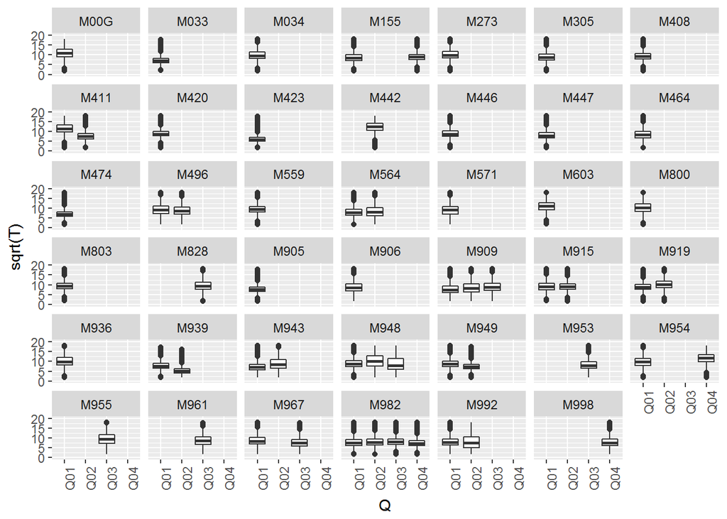

```r
ggplot(dane2, aes(Q, sqrt(T))) + geom_boxplot() + facet_wrap(~M) + theme(axis.text.x = element_text(angle = 90, hjust = 1)) + scale_y_continuous(limits=c(0,20))
```

Okazuje się, że zarówno między zadaniami jak i w obrębie danego zadania mamy istotne różnice między czasem odpowiedzi na podpunkty. Spójrzmy jeszcze jakie są to różnice (odfiltrujmy zatem zadania z tylko jednym podpunktem).

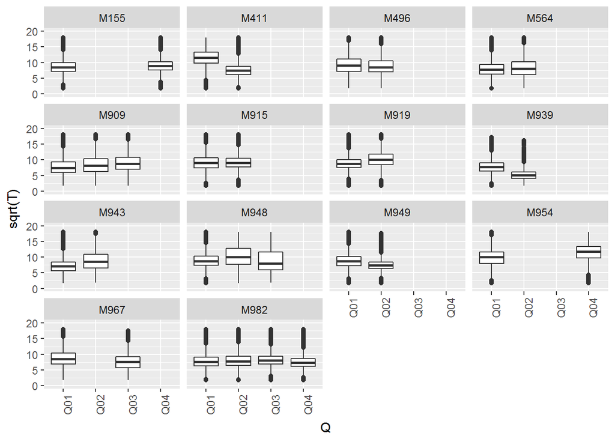

```r
invisible(gc())
ggplot(filter(dane2, M %in% c("M155","M411","M496","M564","M909","M915","M919","M939","M943","M948","M949","M954","M967","M982")), aes(Q, sqrt(T))) + geom_boxplot() + facet_wrap(~M) + theme(axis.text.x = element_text(angle = 90, hjust = 1)) + scale_y_continuous(limits=c(0,20))
```

```r
rm(a3)
```

Patrząc na poszczególne zadania widzimy różnego rodzaju zależności. Choć różnice są istotne, to czasem dalsze podpunkty były wykonywane szybciej, a czasem wolniej. Jesteśmy skłonni uznać, że zarówno numer zadania i numer podpunktu w danym zadaniu mają znaczenie i może to wynikać z tego, że każdy podpunkt jest jak oddzielne zadanie.

### Model 4 i 5 - zależność między czasem (M) a id podpunktu (Q) zagnieżdżonym w id zadania (M) oraz pozycją (position)

```r
invisible(gc())
a4 <- aov(sqrt(T)~M/Q+position, data=dane2)
summary(a4)
```

```
##                 Df  Sum Sq Mean Sq F value Pr(>F)
## M               40 1143498   28587    4149 <2e-16 ***
## position         3  156162   52054    7555 <2e-16 ***
## M:Q             19  262829   13833    2008 <2e-16 ***
## Residuals   999937 6889612       7
## ---
## Signif. codes:  0 '***' 0.001 '**' 0.01 '*' 0.05 '.' 0.1 ' ' 1
```

```r
rm(a4)
```

Uwzględnienie pozycji w kwestionariuszu jest istotne względem modelu opartego na samych id zadań.

```r
invisible(gc())
a5 <- aov(sqrt(T)~position+M/Q, data=dane2)
summary(a5)
```

```
##                 Df  Sum Sq Mean Sq F value Pr(>F)
## position         3  158873   52958    7686 <2e-16 ***
## M               40 1140787   28520    4139 <2e-16 ***
## M:Q             19  262829   13833    2008 <2e-16 ***
## Residuals   999937 6889612       7
## ---
## Signif. codes:  0 '***' 0.001 '**' 0.01 '*' 0.05 '.' 0.1 ' ' 1
```

```r
rm(a5)
```

Podobnie dzieje się, gdy najpierw uwzględnimy pozycję a potem zadania. Wniosek jest taki że wszystkie te zmienne uwzględnimy w ostatecznym modelu. Przyjmij zatem ten model i przeprowadźmy jego diagnostykę.

## Model pierwiastkowy

Spójrzmy na wykresy diagnostyczne naszego ostatecznego modelu (sqrt(T)~position+M/Q).

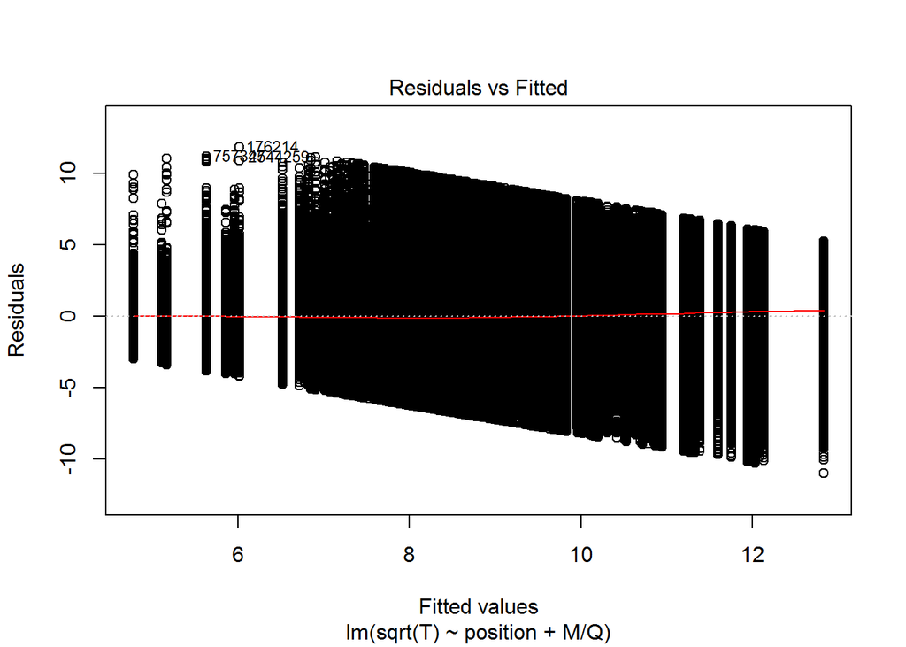

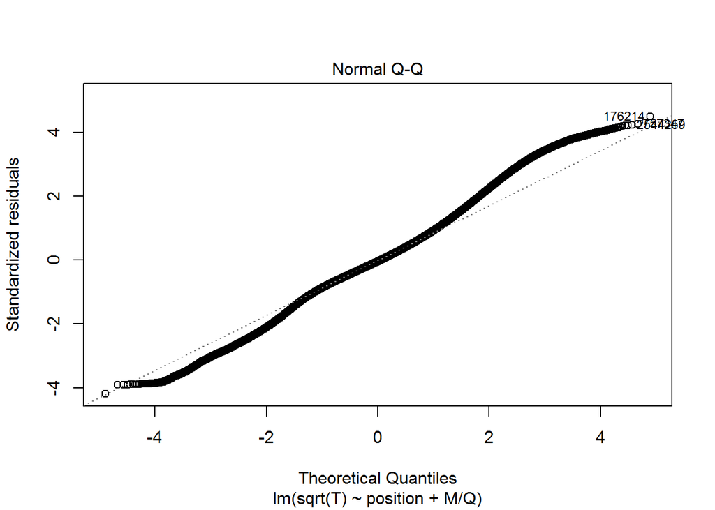

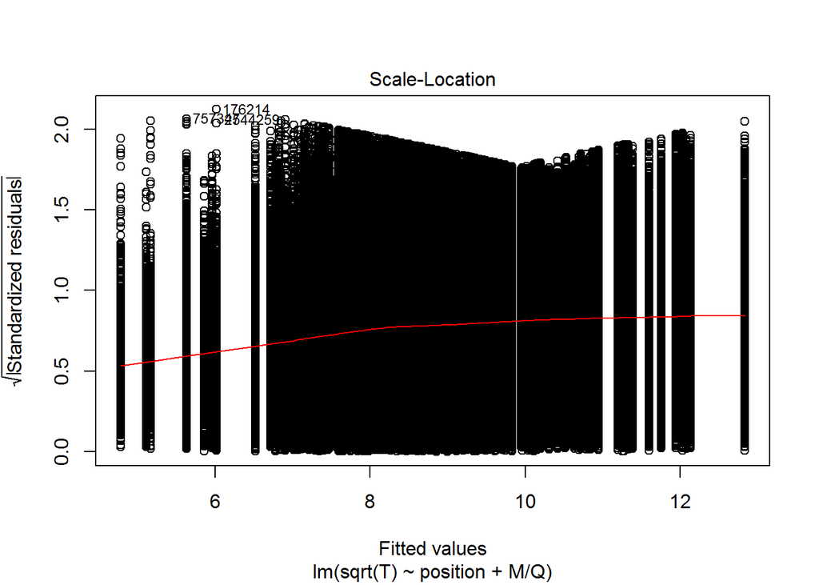

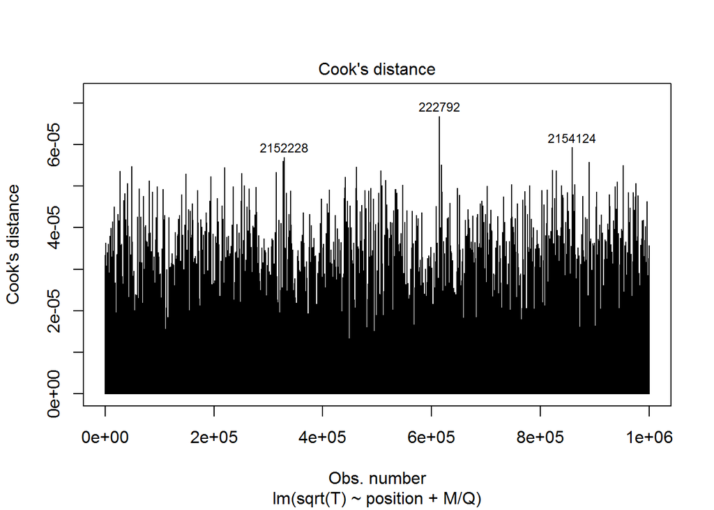

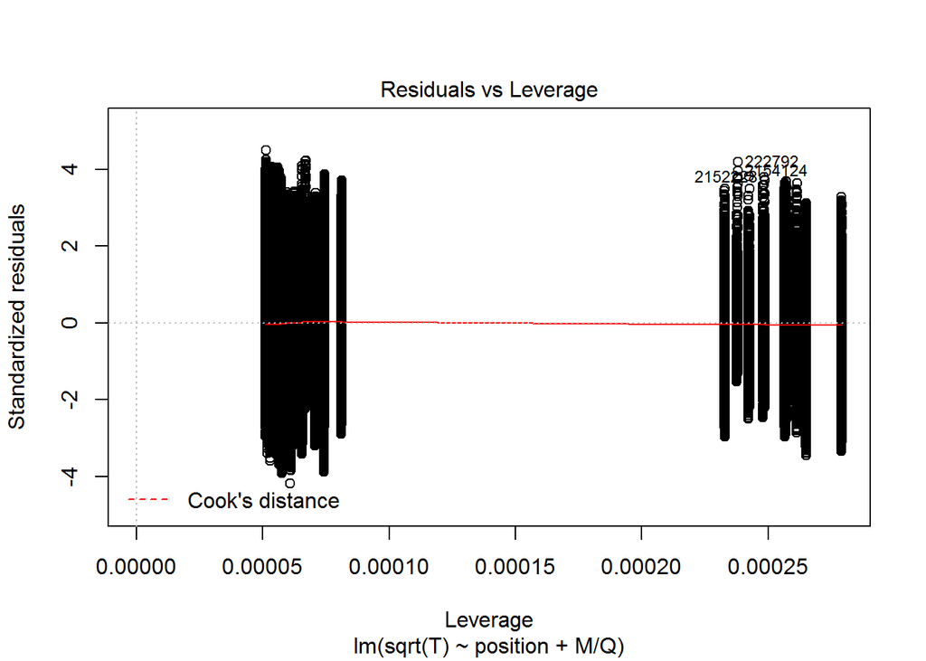

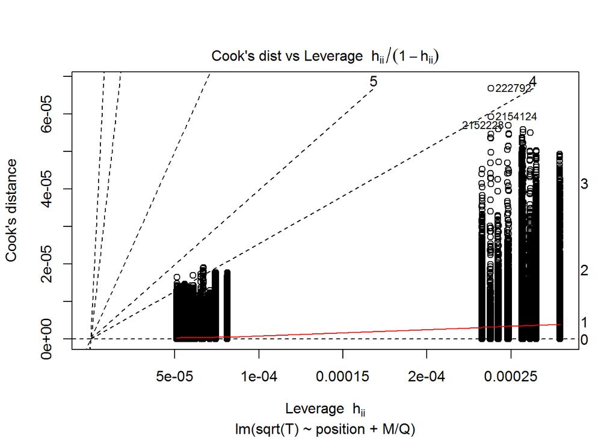

```r
invisible(gc())
model_zad_1 <- lm(sqrt(T)~position+M/Q, data=dane2)
plot(model_zad_1, which=1:6)
```

Wykres 1: “Residuals vs Fitted”: średnie reszty są praktycznie stałe, nie zależą od zmiennej objaśnianej. Werdykt pozytywny. Wykres 2 “Normal Q-Q”: Widzimy odchylenia reszt od rozkładu normalnego. Środkowy przedział pokrywa się jednak całkiem dobrze. Werdykt neutralny. Wykres 3 “Scale Location”: Istnieje niewielka zależność funkcyjna dla wariancji reszt. Wedykt neutralny. Wykres 4 “Cook’s Distance”: Miary Cooka są mikroskopijne. Wedykt pozytywny. Wykres 5 “Residual’s vs Leverage”: Nie obserwujemy nietypowych obserwacji o dużej dźwigni. Werdykt pozytywny. Wykres 6 “Cook’s dist vs Leverage”: Ponownie nie obserwujemy silnie zaburzających obserwacji. Wedykt pozytywny.

Wykonajmy jeszcze test jednorodności wariancji

```r
invisible(gc())
bptest(model_zad_1)
```

```
##
##  studentized Breusch-Pagan test
##
## data:  model_zad_1
## BP = 39650, df = 62, p-value < 2.2e-16
```

Werdykt negatywny.

## Model boxa-coxa

Spróbujmy jeszcze zastosować jak najlepiej dopasowaną transformację z rodziny boxa-coxa, aby poprawić normalność reszt.

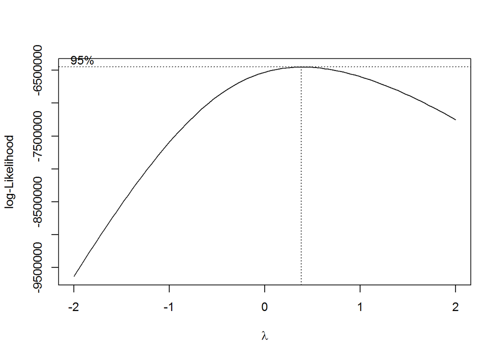

```r
invisible(gc())
wynikBC = boxcox(T~position+M/Q, data=dane2)
```

```r
(wsp = wynikBC$x[which.max(wynikBC$y)])
```

```
## [1] 0.3838384
```

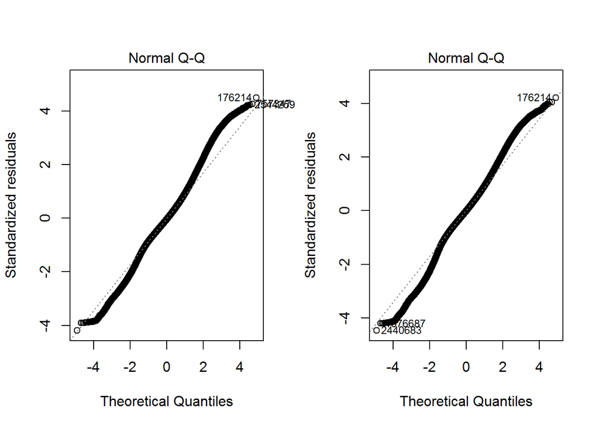

```r
model_zad_2 = lm((T^wsp-1)/wsp~position+M/Q, data=dane2)
par(mfrow = c(1,2))
plot(model_zad_1, which=2)
plot(model_zad_2, which=2)
```

Transformacja nie poprawiła znacząco modelu, zatem pozostajemy przy modelu starym.

## Podsumowanie

Analizując kolejne modele uznaliśmy, że zmienne M, Q oraz position są istotne w modelu. Wybraliśmy model sqrt(T)~position+M/Q. Diagnostyka tego modelu jest dobra, choć reszty nie są do końca normalne. Transformacja boxa-coxa nie pomaga jednak rozwiązać tego problemu.